# lab 3 report

Sarah Greta

## Part 1: Chi-squared test for independence

Data set: number of people in your class who are male vs female, as well as those who prefer clasping their hands with their right thumb of top vs left thumb on top.

| Thumb/ sex | female | male |
| --- | --- | --- |
| right-thumb | 38 | 16 |
| left-thumb | 60 | 41 |

Data set: number of people in your class who are right-handed vs left-handed, as well as those who prefer clasping their hands with their right thumb of top vs left thumb on top.

| Thumb/ hand | right | left |
| --- | --- | --- |
| right-thumb | 41 | 8 |
| left-thumb | 94 | 6 |

Data set: number of habitat sightings for two species of two moray eels of genus **Gymnothorax** in a reef in Belize.

| Habitat | G. moringa | G. vicinus |
| --- | --- | --- |
| Grass | 127 | 116 |
| Sand | 99 | 67 |
| Border | 264 | 161 |

1. From the first data set construct a two-way table with sex and thumb-on-top preferences as the two variables and assign it to an R matrix.

```r
sex.thumb <- matrix(c(38,60,16,41), ncol=2, nrow=2)
```

2. Use the R chi-squared function to calculate the p-value for the data set and decide whether to reject the hypothesis that sex and thumb on top preference are independent at significance levels $\alpha = 0.05, 0.01, 0.001$.

```r
st.test <- chisq.test(sex.thumb)
print(st.test)
```

```
##
##  Pearson's Chi-squared test with Yates' continuity correction
##
## data:  sex.thumb
## X-squared = 1.3783, df = 1, p-value = 0.2404
```

The p-value is 0.2404. For the significance levels of 0.05, 0.01, and 0.001, the null hypothesis would not be rejected.

3. From the second data set construct a two-way table with handedness and thumb-on-top preferences as the two variables and assign it to an R matrix.

```r
hand.thumb <- matrix(c(41,94,8,6), ncol=2, nrow=2)
```

4. Use the R chi-squared function to calculate the p-value for the data set and decide whether to reject the hypothesis that handedness and thumb on top preference are independent at significance levels $\alpha = 0.05, 0.01, 0.001$.

```r
ht.test <- chisq.test(hand.thumb)
print(ht.test)
```

```
##
##  Pearson's Chi-squared test with Yates' continuity correction
##
## data:  hand.thumb
## X-squared = 2.9956, df = 1, p-value = 0.08349
```

The p-value is 0.08349. For the significance levels of 0.05, 0.01, and 0.001, the null hypothesis would not be rejected.

5. Put the marine biology data set in the two-way table above into an R matrix.

```r
eels <- matrix(c(127,99,264,116,67,161), ncol=2, nrow=3)
```

6. Use the R chi-squared function to calculate the p-value for the data set and decide whether to reject the hypothesis that species and habitat are independent at significance levels $\alpha = 0.05, 0.01, 0.001$.

```r
eel.test <- chisq.test(eels)
print(eel.test)
```

```
##
##  Pearson's Chi-squared test
##
## data:  eels
## X-squared = 6.2621, df = 2, p-value = 0.04367
```

The p-value is 0.04367. For the significance levels of 0.05, I would reject the null hypothesis. For the significance levels of 0.01 and 0.001, I would not reject the null hypothesis.

## Part 2: Generating data for hypothesis testing

1. Use the scripts above to generate data sets for genotype A and genotype B of 50 patients with 0.5 probability of hypertension for both data sets. Plot the histograms of both data sets and report whether they look similar. Place the counts into a data matrix and run a chi-squared test on it. Does the test lead to rejection for the independence hypothesis at 0.1 significance level? How about at 0.05? Based on how you generated the data sets, is the hypothesis actually true? Did the chi-squared test get the result right?

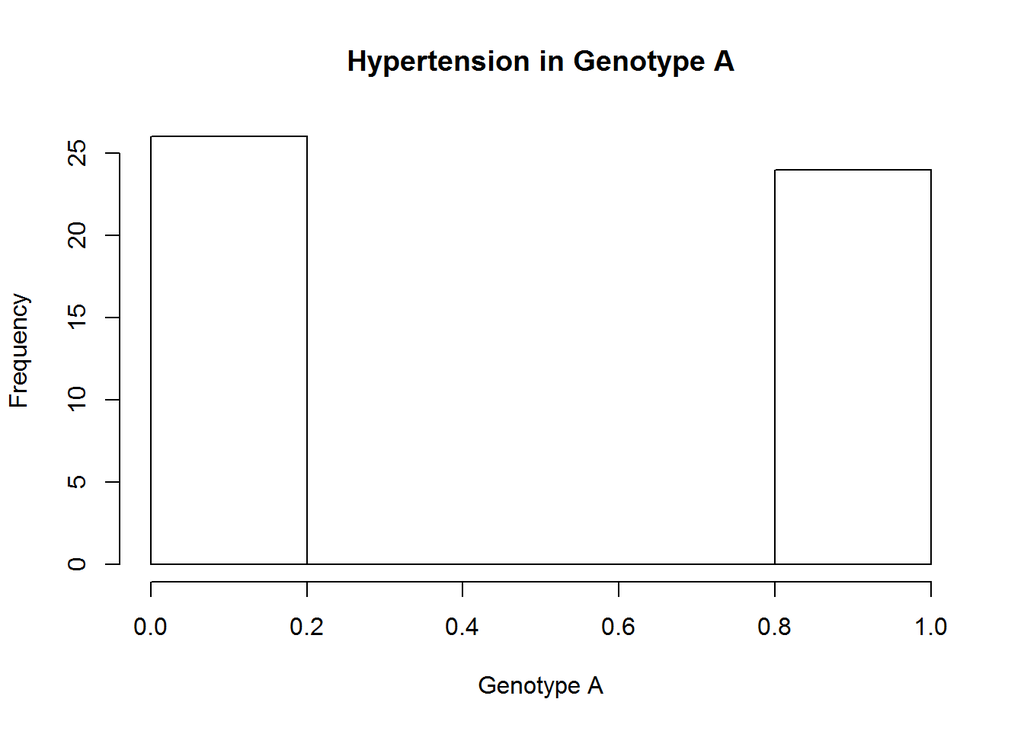

```r
patients <- 50
p.genA <- 0.5
p.genB <- 0.5
dist.genA <- rbinom(patients, 1, p.genA)
dist.genB <- rbinom(patients, 1, p.genB)
hist(dist.genA, main="Hypertension in Genotype A", xlab="Genotype A")
```

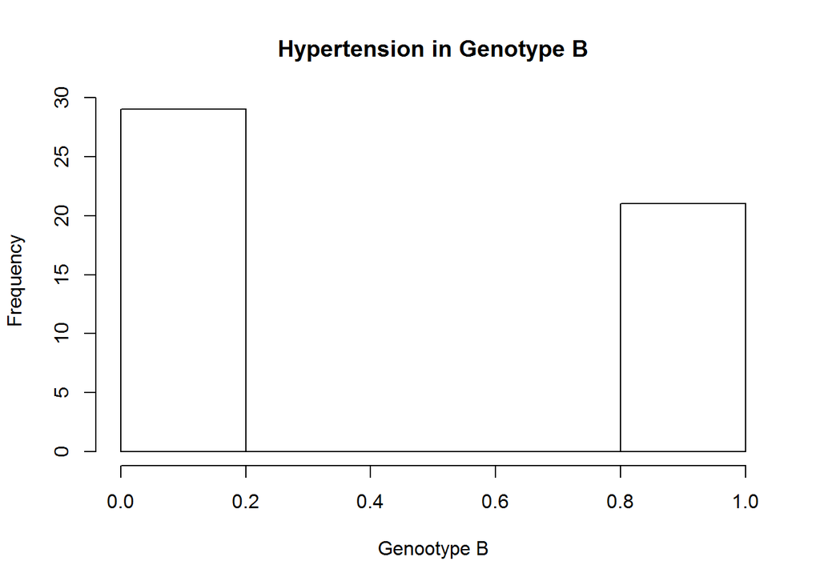

```r
hist(dist.genB, main="Hypertension in Genotype B", xlab="Genootype B")
```

```r
hypertension.data <- matrix(c(table(dist.genA),table(dist.genB)),nrow=2,ncol=2)
print(chisq.test(hypertension.data))
```

```
##
##  Pearson's Chi-squared test with Yates' continuity correction
##
## data:  hypertension.data
## X-squared = 0.16162, df = 1, p-value = 0.6877
```

2. Repeat the code in the first task 100 times by adding a for loop around it. In each loop iteration you generate the two datasets as before (both with probability of hypertension of 0.5), place the counts in a data matrix and perform a chi-squared test for independence of ‘genotype’ and ‘phenotype’ (hypertension). Report how many of the 100 chi-squared tests result in rejection of the null hypothesis at the 0.1 and 0.05 significance level by using *test.output$p.value* to put the p-values in a vector *p.vec* and report how many of the p-values are less than the significance level a (the command *sum(p.vec<a)* will do this.) Based on how you generated the datasets, how many of the test conclusions are **wrong** for each significance level? Explain whether this agrees with the notion of p-value.

```r
N <- 100
p.vec <- rep(NA, N)
a <- 0.1
b <- 0.05
for (i in 1:N) {
dist.genA <- rbinom(patients, 1, p.genA)
dist.genB <- rbinom(patients, 1, p.genB)
hypertension.data <- matrix(c(table(dist.genA),table(dist.genB)),nrow=2,ncol=2)
test.output <- chisq.test(hypertension.data)
p.vec[i] <- test.output$p.value
}
print(sum(p.vec<a))
```

```
## [1] 4
```

```r
print(sum(p.vec<b))
```

```
## [1] 3
```

3. Now let us change the two data sets so they are different, and thus the data are not independent. For the first data set (with genotype A), let the probability of hypertension be 0.4 and for the second data set (genotype B) let hypertension occur with probability 0.6. Count how many of the 100 chi-squared tests result in rejecting the null hypothesis at the 0.1 and 0.05 significance level. Based on how you generated the datasets, how many of the test conclusions are **wrong** for each significance level? Explain whether this agrees with the notion of p-value.

```r
p.genA2 <- 0.4
p.genB2 <- 0.6
p.vec2 <- rep(NA,100)
for (i in 1:N) {
dist.genA2 <- rbinom(patients, 1, p.genA2)
dist.genB2 <- rbinom(patients, 1, p.genB2)
hypertension.data2 <- matrix(c(table(dist.genA2),table(dist.genB2)),nrow=2,ncol=2)
test.output <- chisq.test(hypertension.data2)
p.vec2[i] <- test.output$p.value
}
print(sum(p.vec2<a))
```

```
## [1] 51
```

```r
print(sum(p.vec2<b))
```

```
## [1] 37
```

4. Finally, let’s make it really easy for the chi-squared test, and generate data from very different distributions. For the first data set (with genotype A), let the probability of hypertension be 0.2 and for the second data set (genotype B) let hypertension occur with probability 0.8. Count how many of the 100 chi-squared tests result in rejecting the null hypothesis at the 0.1 and 0.05 significance level. Based on how you generated the datasets, how many of the test conclusions are **wrong** for each significance level? Explain whether this agrees with the notion of p-value.

```r
p.genA3 <- 0.2
p.genB3 <- 0.8
p.vec3 <- rep(NA,100)
for (i in 1:N) {
dist.genA3 <- rbinom(patients, 1, p.genA3)
dist.genB3 <- rbinom(patients, 1, p.genB3)
hypertension.data3 <- matrix(c(table(dist.genA3),table(dist.genB3)),nrow=2,ncol=2)
test.output <- chisq.test(hypertension.data3)
p.vec3[i] <- test.output$p.value
}
print(sum(p.vec3<a))
```

```
## [1] 100
```

```r
print(sum(p.vec3<b))
```

```
## [1] 100
```